### 5번

Visualize the distribution of carat, partitioned by price.

price의 사분위수를 기준으로 범위를 잡아 데이터를 그룹화하여 시각화를 진행하였다.

```r
summary(diamonds$price)
```

```
##    Min. 1st Qu.  Median    Mean 3rd Qu.    Max.
##     326     950    2401    3933    5324   18823
```

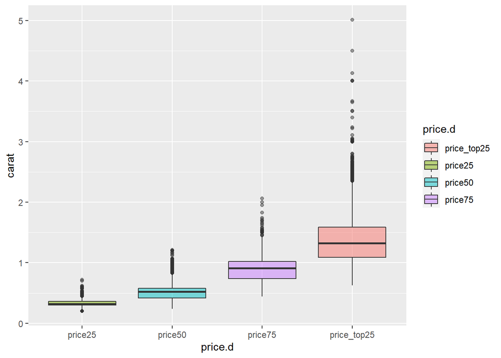

```r
diamonds %>%
  mutate(price.d = ifelse(price<=950,"price25",
                        ifelse(price<=2401,"price50",
                               ifelse(price<=5324,"price75","price_top25"))
                        )
         )%>%
  ggplot()+geom_boxplot(aes(price.d,carat,fill=price.d),alpha=0.5)+
  scale_x_discrete(limits=c("price25","price50","price75","price_top25"))
```

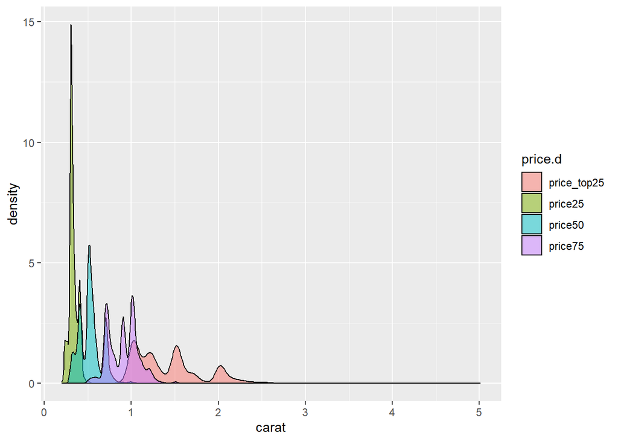

```r
diamonds %>%
  mutate(price.d = ifelse(price<=950,"price25",
                        ifelse(price<=2401,"price50",
                               ifelse(price<=5324,"price75","price_top25"))
                        )
         )%>%
  ggplot()+geom_density(aes(carat,fill=price.d),alpha=0.5)
```

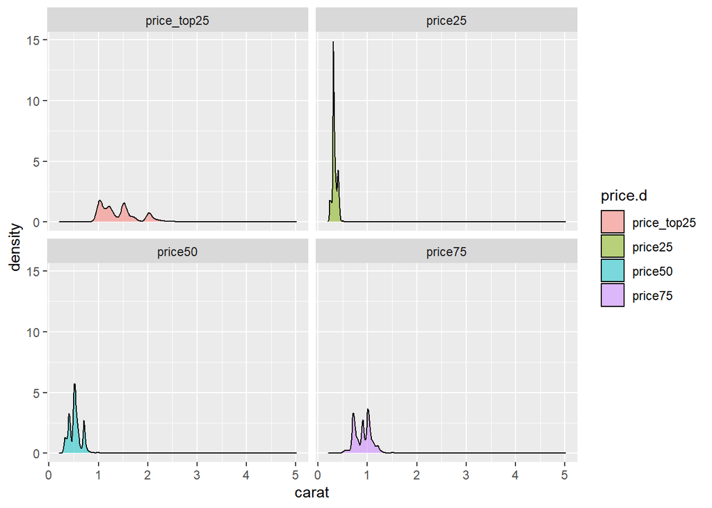

```r
#범주별 나눠서 보기
diamonds %>%
  mutate(price.d = ifelse(price<=950,"price25",
                        ifelse(price<=2401,"price50",
                               ifelse(price<=5324,"price75","price_top25"))
                        )
         )%>%
  ggplot()+geom_density(aes(carat,fill=price.d),alpha=0.5)+facet_wrap(~price.d)
```

가격대가 올라갈수록 carat의 분포는 점점 오른쪽으로 이동하는 것을 확인할 수 있다. 즉, 가격대가 높은 그룹일수록 carat은 대체로 높다고 볼 수 있다.

### 6번

How does the price distribution of very large diamonds compare to small diamonds? Is it as you expect, or does it surprise you?

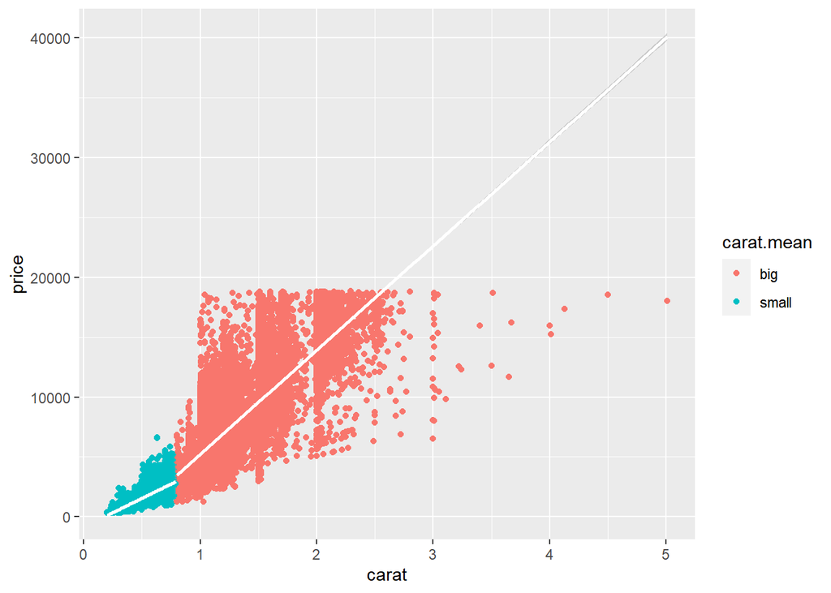

```r
diamonds %>% mutate(carat.mean=ifelse(carat>mean(carat),"big","small")) %>%
  ggplot()+ geom_point(aes(carat,price,color=carat.mean))+
  geom_smooth(aes(carat,price,group=carat.mean),method = "lm",color="white")
```

대체로 (평균기준)큰 다이아일수록 가격이 높고, 회귀 직선이 상대적으로 가파르지만 무조건적으로 큰 다이아라고 작은 다이아보다 비싼 것은 아니다. 따라서 다른 요인들 또한 가격에 영향을 주는 것을 알 수 있다.

### 7번

Combine two of the techniques you’ve learned to visualize the combined distribution of cut, carat, and price.

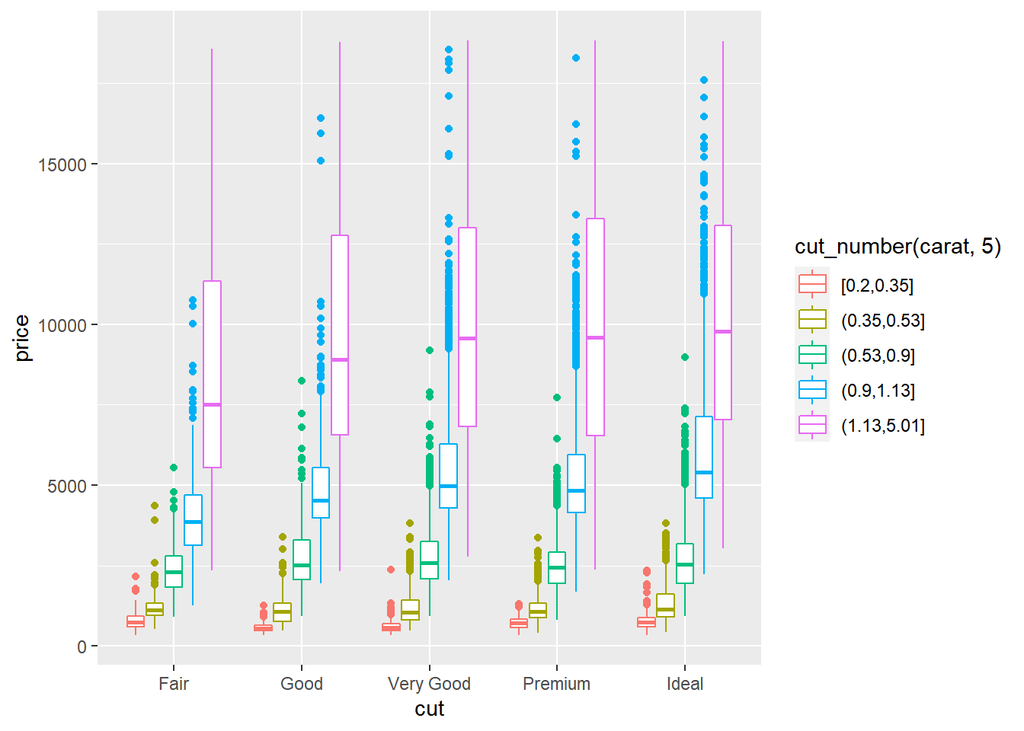

```r
diamonds[,c("price","carat","cut")]->df

ggplot(df, aes(cut, price, color = cut_number(carat, 5))) +
  geom_boxplot()
```

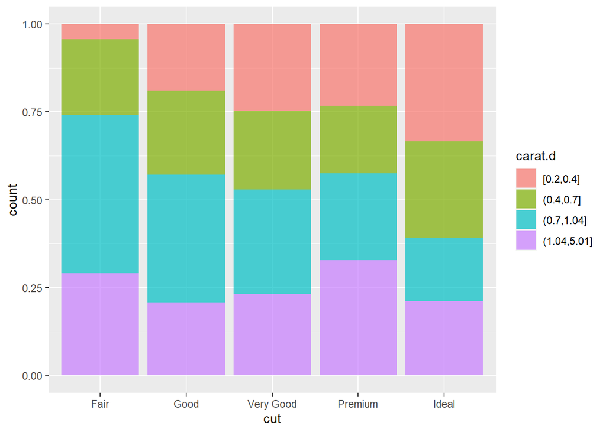

```r
df %>% mutate(carat.d = cut_number(carat, 4),
              price.d = cut_number(price, 4))%>%
ggplot() + geom_bar(aes(x=cut,fill=carat.d),position = "fill",alpha=0.7)
```

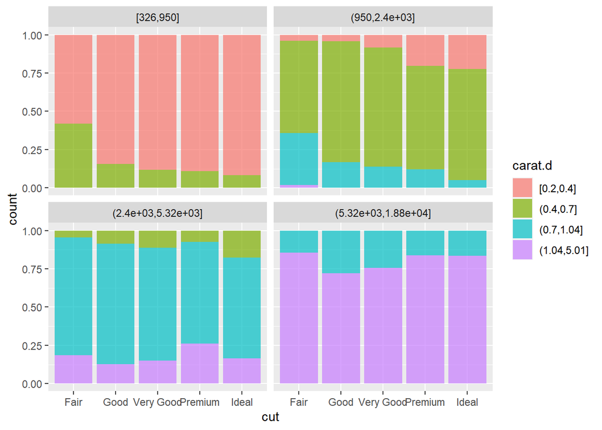

```r
df %>% mutate(carat.d = cut_number(carat, 4),
              price.d = cut_number(price, 4))%>%
ggplot() + geom_bar(aes(x=cut,fill=carat.d),position = "fill",alpha=0.7)+facet_wrap(~price.d)
```

```r
#이 그래프는 두번째 그래프와 달리, price와 carat사이의 관계가 직접적으로 드러난다.
```